# OMICS Integration and Systems Biology Course: Single Cell Omics Integration

Lund, Sweden

Nikolay Oskolkov, SciLifeLab, NBIS Long Term Support, nikolay.oskolkov@scilifelab.se

October 5, 2020

Abstract

In this tutorial, we will go through the Seurat integration across modalities vignette and demonstrate how the Canonical Correlation Analysis (CCA) can be used for integrating scRNAseq and scATACseq data from ~10K PBMC cells sequenced with 10X technology.

### Seurat Single Cell Omics Integration

Seurat is a tool developed by the lab of Rahul Satija to facilitate analysis of Single Cell Omics (scOmics) data. Started as a pipeline tool, i.e. a collection of all known pre-processing and scOmics analysis steps, Seurat developed a few original methods on normalization and batch-effect correction. With the rise of Human Cell Atlas (HCA) consortium, Seurat contributed to ideas on data harmonization across multiple labs and technologies. The ambition of HCA was to develop an Atlas of all human cells from all human tissues, that could serve as a refernce for the future research, i.e. human cells from a particular experiment could have been quickly assigned to a particular cell type without performing the regular single cell analysis steps.

[figure not shown]

Seurat was for a very long time *de-facto* a standard tool for single cell data analysis in 2016-2018, especially in North America, before first two Seurat articles got published in 2018 and 2019. Nowadays, there are alternative single cell analysis workflows, such as SCRAN (lab of John Marioni at EBI) and SCANPY (lab of Fabian Thejs in Munich), that can compete with Seurat. In the first paper of A. Butler et al., **Integrating single cell transcriptomic data across different conditions, technilogies and species** in Nature Biotechnology, 2018, Seurat suggested an interesting modification of the Canonical Correlation Analysis (CCA), that belongs to the same family of algorithms as PLS, OPLS, JIVE and DISCO. The modification was to include an **alignment** of canonical correlation vectors (PLS-components) with the **Dynamic Time Warping (DTW)**, which typically serves as a trajectory similarity measure in Time Series data analysis.

The idea of data integration by Seurat is that CCA delivers components representing linear combinations of features across data sets that are maximally correlated (capture correlation structures across data sets), but not necessarily aligned. Next, Dynamic Time Warping (DTW) is used to locally compress or stretch the vectors during alignment to correct for changes in population density. As a result, the data sets are represented in a single, integrated low-dimensional space.

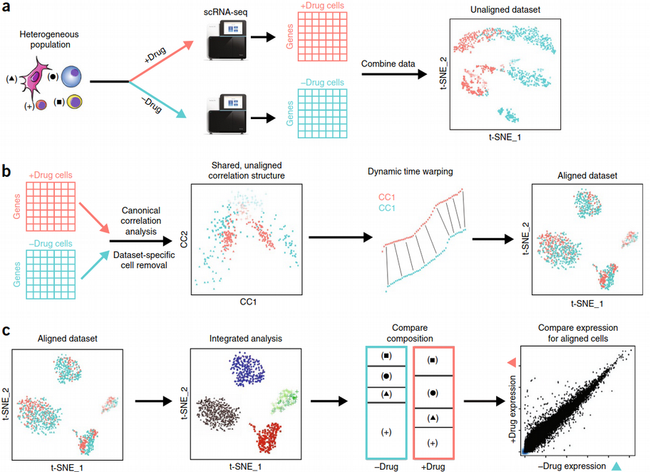

The CCA + DTW strategy was successfully used for data harmonization across multiple conditions, species, labs and technologies. However, those examples were a sort of single cell oriented batch-effect correction that has been known as a big problem in data analysis for years. In other words, despite CCA + DTW offer an impressive integrative framework, possibly adjusted for single cell data analysis, this methodology is for **integration across samples** and not straghtforward to extend to the **integration across Omics**, which is the main challenge and focus of multi-Omics data integration.

Later, Seurat extended the CCA approach for integrating across Omics in the work Stuart et al. 2019, where they used an interesting "anchor" idea borrowed from the Mutual Nearest Neighbors (MNN) algorithm of [Haghverdi et al. 2018](https://www.nature.com/articles/nbt.4091). The idea is based on identifying cells across two Omics that are most similar to each other (anchors), i.e. most likely belong to the same cell population, and align all the rest cells accordingly. This was probably the first true integration across Omics for single cell area.

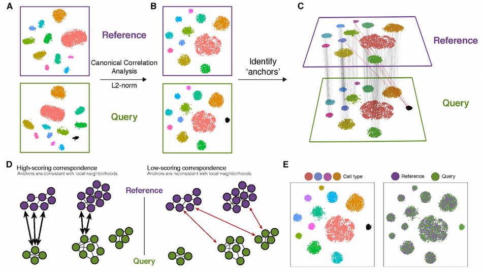

Below, we will demonstrate how to use the "anchors" approach for integrating scRNAseq (9432 cells) and scATACseq (8728 cells) data from PBMC cells. Please note that the two modalities were not measures on the physically same cells but on cells from the same tissue. This was because there was no high-throughput technology available at that time that could produce multiple modalities from the same biological cells. Nowadays, with the advent of 10X Multiome technology, the "anchor" method was replaced by the Weighted Nearest Neighbors (WNN) method.

### Seurat for Integrating scRNAseq and scATACseq from PBMC Cells

First, we load in the provided matrix of ATACseq peaks and collapse the peak matrix to a "gene activity matrix". Here, we make the simplifying assumption that a gene's activity can be quantified by simply summing all counts within the gene body + 2kb upstream. Next we build the Seurat object and store the original peaks as "ATAC" assay. As a QC step, we also filter out all cells here with fewer than 10K total counts in the scATAC-seq data.

```r
library("Seurat")
```

```r
library("ggplot2")
library("Signac")


#### Data download #################################################################################
# You need to download the following file and include it in the same directory as this notebook
#
# https://drive.google.com/uc?export=download&id=1hBeh2L5PC-T87YObCmJv4Qcm59IqkkOf
#
####################################################################################################

#After downloading the file above, download the following:
#download.file('https://cf.10xgenomics.com/samples/cell-atac/1.0.1/atac_v1_pbmc_10k/atac_v1_pbmc_10k_singlecell.csv', method = 'wget', destfile = 'atac_v1_pbmc_10k_singlecell.csv')
#download.file('https://cf.10xgenomics.com/samples/cell-atac/1.0.1/atac_v1_pbmc_10k/atac_v1_pbmc_10k_filtered_peak_bc_matrix.h5', method = 'wget', destfile = 'atac_v1_pbmc_10k_filtered_peak_bc_matrix.h5')
#download.file('https://www.dropbox.com/s/3f3p5nxrn5b3y4y/pbmc_10k_v3.rds?dl=1', method = 'wget', destfile = 'pbmc_10k_v3.rds')

#Gene activity quantification (ATACseq peaks)
peaks <- Read10X_h5("atac_v1_pbmc_10k_filtered_peak_bc_matrix.h5")
dim(peaks)
```

```
## [1] 89796  8728
```

```r
peaks[1:5,1:5]
```

```
## 5 x 5 sparse Matrix of class "dgCMatrix"
##                    AAACGAAAGAGCGAAA-1 AAACGAAAGAGTTTGA-1 AAACGAAAGCGAGCTA-1
## chr1:565107-565550                  .                  .                  .
## chr1:569174-569639                  .                  .                  .
## chr1:713460-714823                  .                  .                  2
## chr1:752422-753038                  .                  .                  .
## chr1:762106-763359                  .                  .                  4
##                    AAACGAAAGGCTTCGC-1 AAACGAAAGTGCTGAG-1
## chr1:565107-565550                  .                  .
## chr1:569174-569639                  .                  .
## chr1:713460-714823                  8                  .
## chr1:752422-753038                  .                  .
## chr1:762106-763359                  2                  .
```

```r
#Here we summed up all peaks overlapping a gene and computed of ATACseq peaks per gene (here we just load an already pre-computed matrix for the sake of time)
activity.matrix <- read.delim("scatacseq_activity_matrix.txt", header = TRUE, row.names = 1, sep="\t")
colnames(activity.matrix)<-gsub("\\.","-",colnames(activity.matrix))
dim(activity.matrix)
```

```
## [1] 18969  8728
```

```r
activity.matrix[1:5,1:5]
```

```
##                AAACGAAAGAGCGAAA-1 AAACGAAAGAGTTTGA-1 AAACGAAAGCGAGCTA-1
## RP5-857K21.4                    0                  0                  0
## RP11-206L10.2                   0                  0                  2
## RP11-206L10.10                  0                  0                  0
## LINC01128                       0                  0                  4
## FAM41C                          0                  0                  0
##                AAACGAAAGGCTTCGC-1 AAACGAAAGTGCTGAG-1
## RP5-857K21.4                    0                  0
## RP11-206L10.2                   8                  0
## RP11-206L10.10                  0                  0
## LINC01128                       3                  0
## FAM41C                          4                  0
```

```r
#Seurat object setup
pbmc.atac <- CreateSeuratObject(counts = peaks, assay = "ATAC", project = "10x_ATAC")
pbmc.atac@assays$ATAC@counts[1:5,1:5]
```

```
## 5 x 5 sparse Matrix of class "dgCMatrix"
##                    AAACGAAAGAGCGAAA-1 AAACGAAAGAGTTTGA-1 AAACGAAAGCGAGCTA-1
## chr1:565107-565550                  .                  .                  .
## chr1:569174-569639                  .                  .                  .
## chr1:713460-714823                  .                  .                  2
## chr1:752422-753038                  .                  .                  .
## chr1:762106-763359                  .                  .                  4
##                    AAACGAAAGGCTTCGC-1 AAACGAAAGTGCTGAG-1
## chr1:565107-565550                  .                  .
## chr1:569174-569639                  .                  .
## chr1:713460-714823                  8                  .
## chr1:752422-753038                  .                  .
## chr1:762106-763359                  2                  .
```

```r
pbmc.atac[["ACTIVITY"]] <- CreateAssayObject(counts = activity.matrix)
pbmc.atac
```

```
## An object of class Seurat
## 108765 features across 8728 samples within 2 assays
## Active assay: ATAC (89796 features, 0 variable features)
##  1 other assay present: ACTIVITY
```

```r
meta<-read.table("atac_v1_pbmc_10k_singlecell.csv",sep=",",header=TRUE,row.names=1,stringsAsFactors=FALSE)
head(meta)
```

```
##                      total duplicate chimeric unmapped lowmapq mitochondrial
## NO_BARCODE         8335327   3922818    71559   746476  634014         22972
## AAACGAAAGAAACGCC-1       3         1        0        1       0             0
## AAACGAAAGAAAGCAG-1      14         1        0        4       2             0
## AAACGAAAGAAAGGGT-1       7         1        0        1       0             0
## AAACGAAAGAAATACC-1    9880      5380       79      106    1120             6
## AAACGAAAGAAATCTG-1       2         0        0        0       0             0
##                    passed_filters cell_id is__cell_barcode TSS_fragments
## NO_BARCODE                2937488    None                0             0
## AAACGAAAGAAACGCC-1              1    None                0             1
## AAACGAAAGAAAGCAG-1              7    None                0             0
## AAACGAAAGAAAGGGT-1              5    None                0             2
## AAACGAAAGAAATACC-1           3189    None                0           386
## AAACGAAAGAAATCTG-1              2    None                0             1
##                    DNase_sensitive_region_fragments enhancer_region_fragments
## NO_BARCODE                                        0                         0
## AAACGAAAGAAACGCC-1                                1                         1
## AAACGAAAGAAAGCAG-1                                2                         0
## AAACGAAAGAAAGGGT-1                                2                         0
## AAACGAAAGAAATACC-1                             1623                       297
## AAACGAAAGAAATCTG-1                                2                         1
##                    promoter_region_fragments on_target_fragments
## NO_BARCODE                                 0                   0
## AAACGAAAGAAACGCC-1                         0                   1
## AAACGAAAGAAAGCAG-1                         0                   2
## AAACGAAAGAAAGGGT-1                         1                   2
## AAACGAAAGAAATACC-1                       107                1758
## AAACGAAAGAAATCTG-1                         1                   2
##                    blacklist_region_fragments peak_region_fragments
## NO_BARCODE                                  0                     0
## AAACGAAAGAAACGCC-1                          0                     1
## AAACGAAAGAAAGCAG-1                          0                     0
## AAACGAAAGAAAGGGT-1                          0                     1
## AAACGAAAGAAATACC-1                         16                   262
## AAACGAAAGAAATCTG-1                          0                     2
```